# Chip-Seq Analysis

Viz

## Introduction

This is a report on the analysis of the raw nucleotide data from a ChIP-Seq experiment performed by the Irish Cancer Society on BreastPredict project. The data focuses on the 21st Chromosome from the Human Genome (Feb. 2009 (GRCh37/hg19) release). The document covers the interrogation of potential regulatory role of a specific transcription factor in a human breast cancer cell line through a full ChIP-seq analysis and includes genome-wide binding location of the same TF along with the expected binding motif which shows a probable TF-DNA interaction and gene regulation.

## Overview of the Analysis

1. Quality Analysis and Control
2. Reference Genome Indexing
3. Read Alignment
4. File Operations
5. Data Analysis
6. Conclusion

## Software Used

- fastqc
  - Fast quality check on fastq data
- bowtie2
  - A fast and sensitive gapped read aligner
- [samtools](http://www.htslib.org/)
  - Samtools is a suite of programs for interacting with high-throughput sequencing data
- [macs2](https://github.com/taoliu/MACS/)
  - Model-based Analysis of ChIP-Seq
- [bedtools](https://bedtools.readthedocs.io/en/latest/)
  - Swiss-army knife of tools for a wide-range of genomics analysis tasks.
- [IGV](https://software.broadinstitute.org/software/igv/)
  - A high-performance visualization tool for interactive exploration of large, integrated genomic datasets.
- bash
  - Standard Linux shell
- [GREAT](http://bejerano.stanford.edu/great/public/html/index.php)
  - GREAT predicts functions of cis-regulatory regions.
- [meme-suite](http://meme-suite.org/)
  - MEME Suite allows the biologist to discover novel motifs in collections of unaligned nucleotide or protein sequences, and to perform a wide variety of other motif-based analyses.
- [rsat](http://rsat.sb-roscoff.fr/peak-motifs_form.cgi)
  - Pipeline for discovering motifs in massive ChIP-seq peak sequences.
- [pavis](https://manticore.niehs.nih.gov/pavis2/)
  - Annotation and visualization of ChIP-seq data

## Preprocessing

### Data

- [chr21.fa](http://hgdownload.soe.ucsc.edu/goldenPath/hg19/chromosomes/chr21.fa.gz) - The reference genome used for the analysis
- chip.fastq - The experiment file with reads of dna that have immunoprecipitated. This forms the case.
  - ChIP-Seq is used to analyse protein interactions with DNA. ChIP-seq combines chromatin immunoprecipitation with massively parallel DNA sequencing to identify the binding sites of DNA-associated proteins.
- input.fastq - The control

### Quality Analysis & Control

The reference chromosome data is first obtained from [UCSC Genome browser](https://genome.ucsc.edu/cgi-bin/hgGateway). It is then loaded into the cluster to start the analysis process. FastQC is used for the initial integrity testing. The module is first loaded onto a cluster node through

```
module load fastqc
time fastqc chip.fastq
```

```
Started analysis of chip.fastq
Approx 5% complete for chip.fastq
Approx 10% complete for chip.fastq
Approx 15% complete for chip.fastq
Approx 20% complete for chip.fastq
Approx 25% complete for chip.fastq
Approx 30% complete for chip.fastq
Approx 35% complete for chip.fastq
Approx 40% complete for chip.fastq
Approx 45% complete for chip.fastq
Approx 50% complete for chip.fastq
Approx 55% complete for chip.fastq
Approx 60% complete for chip.fastq
Approx 65% complete for chip.fastq
Approx 70% complete for chip.fastq
Approx 75% complete for chip.fastq
Approx 80% complete for chip.fastq
Approx 85% complete for chip.fastq
Approx 90% complete for chip.fastq
Approx 95% complete for chip.fastq
Analysis complete for chip.fastq

real    0m8.209s
user    0m12.346s
sys 0m0.311s
```

```
time fastqc input.fastq
```

```
Started analysis of input.fastq
Approx 5% complete for input.fastq
Approx 10% complete for input.fastq
Approx 15% complete for input.fastq
Approx 20% complete for input.fastq
Approx 25% complete for input.fastq
Approx 30% complete for input.fastq
Approx 35% complete for input.fastq
Approx 40% complete for input.fastq
Approx 45% complete for input.fastq
Approx 50% complete for input.fastq
Approx 55% complete for input.fastq
Approx 60% complete for input.fastq
Approx 65% complete for input.fastq
Approx 70% complete for input.fastq
Approx 75% complete for input.fastq
Approx 80% complete for input.fastq
Approx 85% complete for input.fastq
Approx 90% complete for input.fastq
Approx 95% complete for input.fastq
Approx 100% complete for input.fastq
Analysis complete for input.fastq

real    0m7.193s
user    0m10.638s
sys 0m0.282s
```

#### FastQC Reports

FastQC reports should that the data from ChIP-seq was good so no further correction needs to be done on the data. (Further report can be found in the files below)

- QC on chip.fastq
- QC on input.fastq

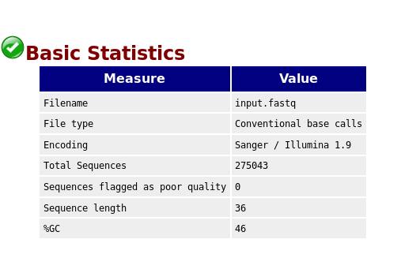

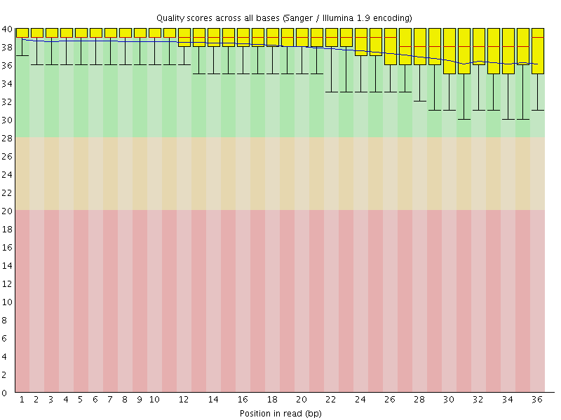

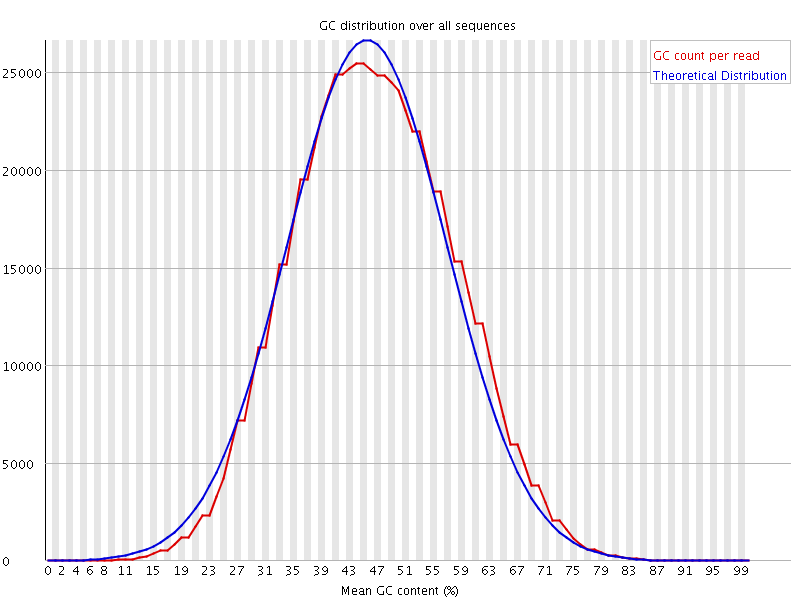

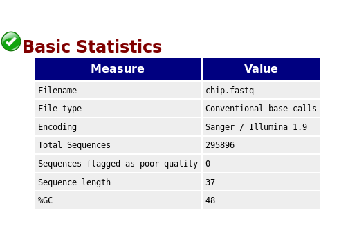

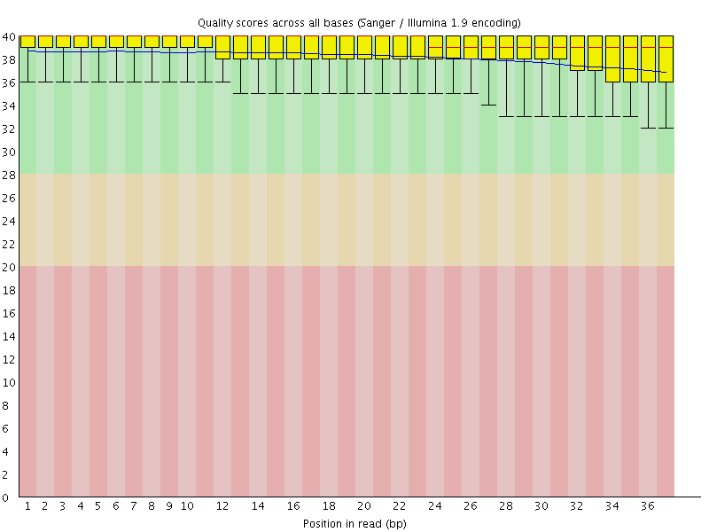

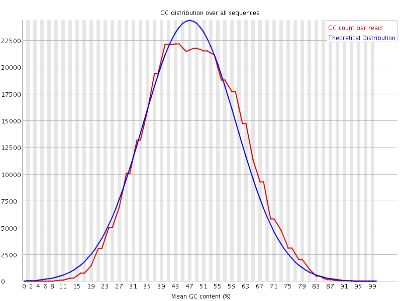

### Reference Genome Indexing

The reference genome has to be indexed in order to align the reads properly. The indexing is done with bowtie. Bowtie2 is an ultrafast and memory-efficient tool for aligning sequencing reads to long reference sequences. It is particularly good at aligning reads of about 50 up to 100s or 1,000s of characters, and particularly good at aligning to relatively long (e.g. mammalian) genomes. Hence it was chosen.

```
module load bowtie
##bowtie splits the files into chunks(with .bt2 extension). hg19 is the prefix to each file
bowtie2-build chr21.fa hg19
```

[output not shown]

[output cut: 521 more lines]

[output not shown]

```
hg19.1.bt2  hg19.2.bt2  hg19.3.bt2  hg19.rev.1.bt2  hg19.rev.2.bt2
```

### Read Alignment

Now the case and control files are aligned to the indexed reference chromosome

```
bowtie2 -x hg19 -U input.fastq -S input.sam
```

```
275043 reads; of these:
  275043 (100.00%) were unpaired; of these:
    4276 (1.55%) aligned 0 times
    247717 (90.06%) aligned exactly 1 time
    23050 (8.38%) aligned >1 times
98.45% overall alignment rate

real    0m20.599s
user    0m20.360s
sys 0m0.135s
```

```
bowtie2 -x hg19 -U chip.fastq -S chip.sam
```

```
295896 reads; of these:
  295896 (100.00%) were unpaired; of these:
    4552 (1.54%) aligned 0 times
    275689 (93.17%) aligned exactly 1 time
    15655 (5.29%) aligned >1 times
98.46% overall alignment rate

real    0m20.671s
user    0m20.436s
sys 0m0.134s
```

The sequences align at a rate > 95%

### File Operations

The aligned sequences are post-processed to compress them into binary files, remove duplicates, sort and index them. Samtools is used for the post-processing

```
module load samtools
time samtools view -Sb input.sam > input.bam  ##Compresses sam files to bam(binary) files
time samtools view -Sb chip.sam > chip.bam
samtools rmdup input.bam input.nodup.bam  ##Remove duplicates from the binary sequence files
samtools rmdup chip.bam chip.nodup.bam
time samtools sort chip.nodup.bam chip.nodup.sorted.bam   ##Sort the sequences based on their leftmost coordinates
time samtools sort input.nodup.bam input.nodup.sorted.bam
time samtools index chip.nodup.sorted.bam  ##Index the binary files
time samtools index input.nodup.sorted.bam
time samtools flagstat chip.nodup.sorted.bam > chip.flagstat.txt  ##Get the statistics of the alignment files
time samtools flagstat input.nodup.sorted.bam > input.flagstat.txt
diff -y chip.flagstat.txt input.flagstat.txt ##Display the difference between the statistics
```

The corresponding outputs from the above commands are given below

```
+ samtools view -Sb input.sam
[samopen] SAM header is present: 1 sequences.

real    0m3.376s
user    0m3.278s
sys 0m0.047s

+ samtools view -Sb chip.sam
[samopen] SAM header is present: 1 sequences.

real    0m3.444s
user    0m3.305s
sys 0m0.068s

+ samtools rmdup input.bam input.nodup.bam
[bam_rmdup_core] processing reference chr21...

+ samtools rmdup chip.bam chip.nodup.bam
[bam_rmdup_core] processing reference chr21...

+ diff -y chip.flagstat.txt input.flagstat.txt
295896 + 0 in total (QC-passed reads + QC-failed reads)       | 275043 + 0 in total (QC-passed reads + QC-failed reads)
0 + 0 duplicates                        0 + 0 duplicates
291344 + 0 mapped (98.46%:nan%)                   | 270767 + 0 mapped (98.45%:nan%)
0 + 0 paired in sequencing                  0 + 0 paired in sequencing
0 + 0 read1                         0 + 0 read1
0 + 0 read2                         0 + 0 read2
0 + 0 properly paired (nan%:nan%)               0 + 0 properly paired (nan%:nan%)
0 + 0 with itself and mate mapped               0 + 0 with itself and mate mapped
0 + 0 singletons (nan%:nan%)                    0 + 0 singletons (nan%:nan%)
0 + 0 with mate mapped to a different chr           0 + 0 with mate mapped to a different chr
0 + 0 with mate mapped to a different chr (mapQ>=5)     0 + 0 with mate mapped to a different chr (mapQ>=5)
```

## Data Analysis

Putative regions where transcription factors binds to the chromosome are isolated through peak calling. Peak calling is a computational method used to identify areas in a genome that have been enriched with aligned reads as a consequence of performing a ChIP-sequencing experiment. Peaks correspond to areas which are “overexpressed”. MACS2 is used to call peaks.

```
time macs2 callpeak -t chip.nodup.sorted.bam -c input.nodup.sorted.bam -f BAM -g hs -n macs_out --call-summits -B
```

```
INFO  @ Wed, 06 Feb 2019 21:52:06:
# Command line: callpeak -t chip.nodup.sorted.bam -c input.nodup.sorted.bam -f BAM -g hs -n macs_out --call-summits -B
# ARGUMENTS LIST:
# name = macs_out
# format = BAM
# ChIP-seq file = ['chip.nodup.sorted.bam']
# control file = ['input.nodup.sorted.bam']
# effective genome size = 2.70e+09
# band width = 300
# model fold = [5, 50]
# qvalue cutoff = 5.00e-02
# Larger dataset will be scaled towards smaller dataset.
# Range for calculating regional lambda is: 1000 bps and 10000 bps
# Broad region calling is off
# Paired-End mode is off
# Searching for subpeak summits is on

INFO  @ Wed, 06 Feb 2019 21:52:06: #1 read tag files...
INFO  @ Wed, 06 Feb 2019 21:52:06: #1 read treatment tags...
INFO  @ Wed, 06 Feb 2019 21:52:09: #1.2 read input tags...
INFO  @ Wed, 06 Feb 2019 21:52:11: #1 tag size is determined as 37 bps
INFO  @ Wed, 06 Feb 2019 21:52:11: #1 tag size = 37
INFO  @ Wed, 06 Feb 2019 21:52:11: #1  total tags in treatment: 291344
INFO  @ Wed, 06 Feb 2019 21:52:11: #1 user defined the maximum tags...
INFO  @ Wed, 06 Feb 2019 21:52:11: #1 filter out redundant tags at the same location and the same strand by allowing at most 1 tag(s)
INFO  @ Wed, 06 Feb 2019 21:52:11: #1  tags after filtering in treatment: 201491
INFO  @ Wed, 06 Feb 2019 21:52:11: #1  Redundant rate of treatment: 0.31
INFO  @ Wed, 06 Feb 2019 21:52:11: #1  total tags in control: 270767
INFO  @ Wed, 06 Feb 2019 21:52:11: #1 user defined the maximum tags...
INFO  @ Wed, 06 Feb 2019 21:52:11: #1 filter out redundant tags at the same location and the same strand by allowing at most 1 tag(s)
INFO  @ Wed, 06 Feb 2019 21:52:11: #1  tags after filtering in control: 266339
INFO  @ Wed, 06 Feb 2019 21:52:11: #1  Redundant rate of control: 0.02
INFO  @ Wed, 06 Feb 2019 21:52:11: #1 finished!
INFO  @ Wed, 06 Feb 2019 21:52:11: #2 Build Peak Model...
INFO  @ Wed, 06 Feb 2019 21:52:11: #2 looking for paired plus/minus strand peaks...
INFO  @ Wed, 06 Feb 2019 21:52:11: #2 number of paired peaks: 1901
INFO  @ Wed, 06 Feb 2019 21:52:11: start model_add_line...
INFO  @ Wed, 06 Feb 2019 21:52:11: start X-correlation...
INFO  @ Wed, 06 Feb 2019 21:52:11: end of X-cor
INFO  @ Wed, 06 Feb 2019 21:52:11: #2 finished!
INFO  @ Wed, 06 Feb 2019 21:52:11: #2 predicted fragment length is 300 bps
INFO  @ Wed, 06 Feb 2019 21:52:11: #2 alternative fragment length(s) may be 300 bps
INFO  @ Wed, 06 Feb 2019 21:52:11: #2.2 Generate R script for model : macs_out_model.r
INFO  @ Wed, 06 Feb 2019 21:52:11: #3 Call peaks...
INFO  @ Wed, 06 Feb 2019 21:52:11: #3 Going to call summits inside each peak ...
INFO  @ Wed, 06 Feb 2019 21:52:11: #3 Pre-compute pvalue-qvalue table...
INFO  @ Wed, 06 Feb 2019 21:52:14: #3 In the peak calling step, the following will be performed simultaneously:
INFO  @ Wed, 06 Feb 2019 21:52:14: #3   Write bedGraph files for treatment pileup (after scaling if necessary)... macs_out_treat_pileup.bdg
INFO  @ Wed, 06 Feb 2019 21:52:14: #3   Write bedGraph files for control lambda (after scaling if necessary)... macs_out_control_lambda.bdg
INFO  @ Wed, 06 Feb 2019 21:52:14: #3   Pileup will be based on sequencing depth in treatment.
INFO  @ Wed, 06 Feb 2019 21:52:14: #3 Call peaks for each chromosome...
INFO  @ Wed, 06 Feb 2019 21:52:22: #4 Write output xls file... macs_out_peaks.xls
INFO  @ Wed, 06 Feb 2019 21:52:22: #4 Write peak in narrowPeak format file... macs_out_peaks.narrowPeak
INFO  @ Wed, 06 Feb 2019 21:52:22: #4 Write summits bed file... macs_out_summits.bed
INFO  @ Wed, 06 Feb 2019 21:52:22: Done!

real    0m18.544s
user    0m16.744s
sys 0m1.912s
```

The above command produces the following output files. macs_out_peaks.xls has all the peak spanning locations on the chromosome.

```
>$ls macs_out*
macs_out_control_lambda.bdg  macs_out_model.r  macs_out_peaks.narrowPeak  macs_out_peaks.xls  macs_out_summits.bed  macs_out_treat_pileup.bdg
```

### Data Visualization

Peaks are visualizde using [IGV](https://software.broadinstitute.org/software/igv/). It cn be used to compare and eliminate possible peak differences between case and control samples. This can help us narrow down the putation binding positions of the TF in the future steps.

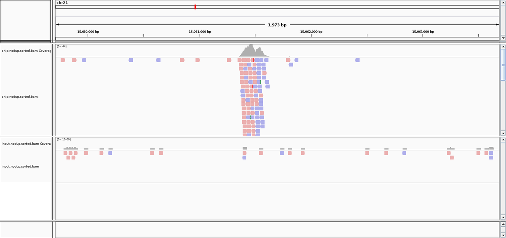

*A Huge peak difference between case and control*

### Analysis

The peak positions are isolated from the macs output and saved as a bed file

```
awk '{print ($1"\t"$2"\t"$3)}' macs_out_peaks.xls > peaks.bed
tail -n +30 peaks.bed > peaks_no_header.bed  ##Removes the headers and comments from the xls file
head peaks_no_header.bed
```

```
chr21   9478966 9479334
chr21   9488140 9488479
chr21   9825338 9827051
chr21   9882928 9883227
chr21   10576105        10576614
chr21   10924251        10924815
chr21   11026478        11027107
chr21   11144289        11144781
chr21   14724142        14724644
chr21   14765889        14766285
```

The peaks_no_header.bed is then uploaded onto [GREAT](http://bejerano.stanford.edu/great/public/html/index.php) for function prediction of *cis*-regulatory regions.

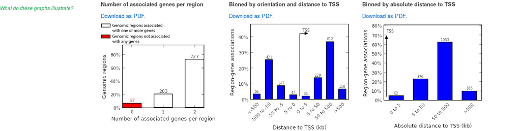

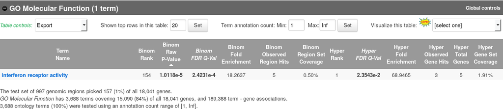

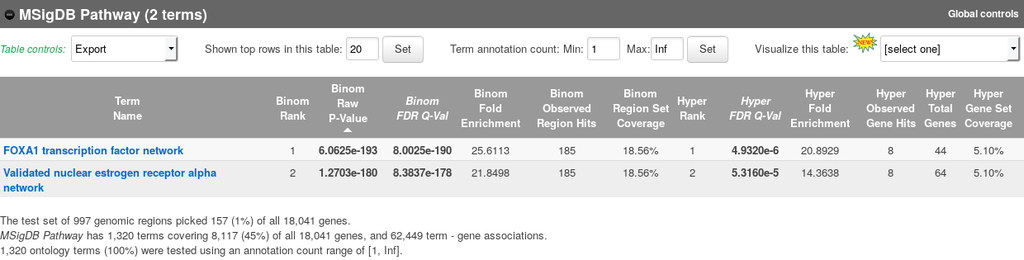

[figure not shown]

[figure not shown]

Based on the above reports from GREAT, it is evident that the pathways involved in the regulatory expression of the TF lies in the FOXA1 and the estrogen receptor network. As [this](https://www.nature.com/articles/ng.730) paper suggests, FOXA1 is a key determinant of estrogen receptor function and endocrine response. Thus we can assume from the above reports that the TF in question is related to the estrogen receptors.

For further annotations of the genes near the peaks, [PAVIS](https://manticore.niehs.nih.gov/pavis2) is used. PAVIS does not provide a broad spectrum of information but rather quickly annotates the genes from the peak positions and also gives a handy report on gene distribution with respect to the peaks.

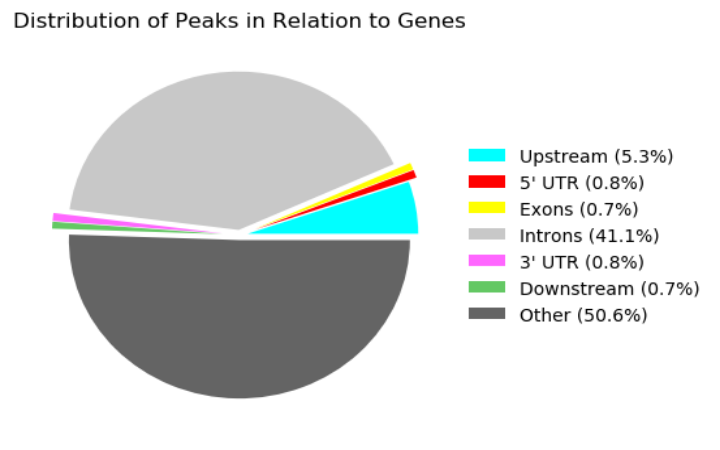

#### Gene Annotation by PAVIS

```r
peaks<-read.csv(file = "/home/rstudio/Data/broad_bread.csv")
head(peaks)
```

| Category | Chromosome | Loci.Start | Loci.End | Gene.ID | Gene.Symbol | Strand | Distance.to.TSS | Description | Conservation.Score | Fractional.Overlaping | pseudo | variant | RNA.fam | RNA | NA. | NA..1 |
| --- | --- | --- | --- | --- | --- | --- | --- | --- | --- | --- | --- | --- | --- | --- | --- | --- |
| Upstream | chr21 | 9825338 | 9827051 | uc021wgw.1 | MIR3687 | + | -8 | Homo sapiens microRNA 3687 (MIR3687) | microRNA. | NA | NA |  |  |  | NA | NA |
| Intron | chr21 | 10576105 | 10576614 | uc011abv.2 | AK311573 | - | 21083 | Homo sapiens cDNA | FLJ18615. | NA | NA |  |  |  | NA | NA |
| Intron | chr21 | 10924251 | 10924815 | uc002yis.1 | TPTE | - | 114896 | Homo sapiens transmembrane phosphatase with tensin homology (TPTE) | transcript variant 2 | mRNA. | NA | NA |  |  | NA | NA |
| 5’UTR | chr21 | 11026478 | 11027107 | uc002yis.1 | TPTE | - | 12637 | Homo sapiens transmembrane phosphatase with tensin homology (TPTE) | transcript variant 2 | mRNA. | NA | NA |  |  | NA | NA |
| Intron | chr21 | 14994757 | 14995125 | uc002yjb.1 | POTED | + | 12444 | Homo sapiens POTE ankyrin domain family | member D (POTED) | mRNA. | NA | NA |  |  | NA | NA |
| Intron | chr21 | 15000171 | 15000534 | uc002yjb.1 | POTED | + | 17855 | Homo sapiens POTE ankyrin domain family | member D (POTED) | mRNA. | NA | NA |  |  | NA | NA |

```r
attach(peaks)
peaks.sorted<-peaks[order( as.numeric((Strand)), Distance.to.TSS),]
detach(peaks)
attach(peaks.sorted)
```

First 20 genes sorted according to the strand direction and distance from TSS

```r
head(unique(peaks.sorted[as.numeric(Strand)==2,"Gene.Symbol"]),n = 20) #positive strand
```

```
##  [1] BC035642     USP25        ABCC13       UMODL1       IGSF5
##  [6] DSCAM-AS1    IFNAR2       MIR3197      DOPEY2       LOC100506385
## [11] COL18A1      TRAPPC10     DYRK1A       NCAM2        PRMT2
## [16] LINC00111    LINC00160    MIR3687      LINC00161    MIR155
## 136 Levels: ABCC13 ADARB1 AGPAT3 AIRE AK311573 ANKRD20A11P APP ... YBEY
```

```r
head(unique(peaks.sorted[as.numeric(Strand)==1,"Gene.Symbol"]),n = 20)  #negative strand
```

```
##  [1] SNORA80      LOC284837    C2CD2        TFF3         SIK1
##  [6] C21orf88     MIR4760      DSCR3        LINC00317    LOC100288432
## [11] C21orf2      COL18A1-AS1  BRWD1-IT2    U3           LINC00323
## [16] NRIP1        SSR4P1       LINC00479    PTTG1IP      TFF1
## 136 Levels: ABCC13 ADARB1 AGPAT3 AIRE AK311573 ANKRD20A11P APP ... YBEY
```

The annotated genes show some interesting caandidates for TF binding (TFF1, PRMT2 for eg).

The sequences from the peak positions are extracted for further analysis using bedtools.

```
bedtools getfasta -fi chr21.fa -bed peaks_no_header.bed  -fo seq_output.fasta
```

seq_output.fasta contains all the sequences which are covered by peaks

```
awk '/^>/{f=!d[$1];d[$1]=1}f' seq_output.fasta > seq_nodup_output1.fasta  ##This command removes the duplicate sequence headers
head seq_nodup_output1.fasta ##Displays the first 10 lines of the positions
```

```
>chr21:9478966-9479334
agtgcaagagtgaacacacactttgtttcggctttaaagaacccagcacgaagccagtct…
>chr21:9488140-9488479
ataaaagtcacttggtcagcagttgttgaagctgaacttggaatctaggtctgtctgacc…
>chr21:9825338-9827051
NNNNNNNNNNNNNNNNNNNNNNNNNNNNNNNNNNNNNNNNNNNNNNNNNNNNNNNNNNNN…
>chr21:9882928-9883227
agggttagggttaggggttagggttagggtcaggggttaggggtcaggggttaggggtca…
>chr21:10576105-10576614
TATTTTAAATATAATAAACGTGTCAAAAATGTGGTTTCGTACTTTTTATAAATTGATATA…
```

### Motif Discovery

#### *Motif analysis and discovery was performed multiple times using different known motif databases to check for convergence*

A sequence motif is a nucleotide or amino-acid sequence pattern that is widespread and has, or is conjectured to have, a biological significance. Motifs span several nucleotides of varied lengths and are highly probable TFs binding sites. The seq_nodup_output1.fasta file is used for comprehensive motif analysis & discovery.

#### MEME-ChIP

MEME-ChIP is used for motif analysis and discovery. Since MEME is used for smaller datasets, MEME-ChIP is the better option for larger datasets. MEME-ChIP is a pipeline which:

- Isolates the most frequently occurring sequence length (fasta-most)
- Outputs the length portion of the sequence centred on the original sequence (fasta-center)
- Shuffle each sequence in a file of fasta sequences without shuffling the order of the sequences (fasta-shuffle-letter)
- Estimate a Markov model from the shuffled sequences (fasta-get-markov)
- Motif discovery (meme)
- Find discriminative regular expressions (dreme)
- Local motif enrichment analysis (centrimo)
- Search for existing motifs from a database (tomtom)
- Looks for significant spacings between a primary motif and each motif in a library of secondary motifs (spamo)
- Scan a set of sequences for motifs (fimo)

(It automatically calculates the background score)

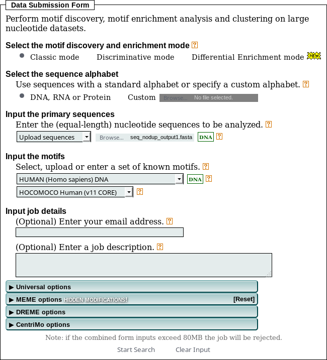

*MEME-ChIP Submission Form:(Up)*

The seq_nodup_output1.fasta file is used as the primary sequence list. The motif analysis is performed and the resulting motifs found are cros-checked from a database of known motifs.

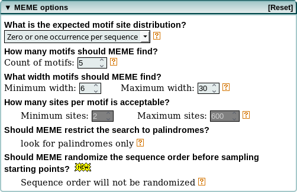

*MEME-Options:(Up)*

The options chosen for the MEME analysis are:

- The distribution of the motifs are assumed to be ‘Zero or one occurence per sequence’. It is more lenient and a balanced assumption when the distribution itself is only partially known or obfuscated.
- The expected count of motifs that MEME should find before it confirms any significance is 5. It also acts as defult upper limit to stop running the algorithm.
- Width of the motifs are assumed to be between 6 and 30. Since we need to estimate the binding sites of the TF, a larger width is chosen.
- An overall E-value of 0.05 is chosen. Any motif below this threshold is discarded as non-significant.

The above parameters gave several motifs, out of which two with the good matches are chosen.

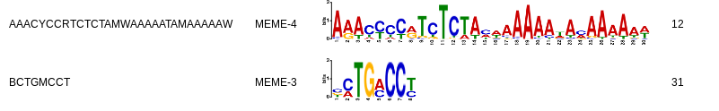

##### [HOCOMO v11](http://hocomoco11.autosome.ru/)

HOmo sapiens COmprehensive MOdel COllection (HOCOMOCO) v11 provides transcription factor (TF) binding models (binding profiles or binding motifs) for human transcription factors. It contains 771 known motifs. The first analysis is done using HOCOMO v11(Full) as the input motif database.

```
    Starting MEME-ChIP
    meme-chip -oc . -time 300 -ccut 100 -fdesc description -order 1 -db db/HUMAN/HOCOMOCOv11_full_HUMAN_mono_meme_format.meme -meme-mod zoops -meme-minw 6 -meme-maxw 30 -meme-nmotifs 5 -meme-searchsize 100000 -dreme-e 0.05 -centrimo-score 5.0 -centrimo-ethresh 10.0 seq_nodup_output1.fasta
    MEME-ChIP is starting subprocess getsize
    getsize ./seq_nodup_output1.fasta 1> $metrics
    MEME-ChIP subprocess getsize ran successfully in 0.0 seconds
    MEME-ChIP is starting subprocess fasta-most
    fasta-most -min 50 < ./seq_nodup_output1.fasta 1> $metrics
    MEME-ChIP subprocess fasta-most ran successfully in 0.2 seconds
    MEME-ChIP is starting subprocess fasta-center
    fasta-center -dna -len 100 < ./seq_nodup_output1.fasta 1> ./seqs-centered
    MEME-ChIP subprocess fasta-center ran successfully in 0.2 seconds
    MEME-ChIP is starting subprocess fasta-shuffle-letters
    fasta-shuffle-letters ./seqs-centered ./seqs-shuffled -kmer 2 -tag -dinuc -dna -seed 1
    MEME-ChIP subprocess fasta-shuffle-letters ran successfully in 0.0 seconds
    MEME-ChIP is starting subprocess fasta-get-markov
    fasta-get-markov -nostatus -nosummary -dna -m 1 ./seq_nodup_output1.fasta ./background
    MEME-ChIP subprocess fasta-get-markov ran successfully in 0.0 seconds
    MEME-ChIP is starting subprocess meme
    meme ./seqs-centered -oc meme_out -mod zoops -nmotifs 5 -minw 6 -maxw 30 -bfile ./background -dna -searchsize 100000 -time 5082 -revcomp -nostatus
    MEME-ChIP subprocess meme ran successfully in 3978.2 seconds
    MEME-ChIP is starting subprocess dreme
    dreme -verbosity 1 -oc dreme_out -png -dna -p ./seqs-centered -n ./seqs-shuffled -t 5548 -e 0.05
    MEME-ChIP subprocess dreme ran successfully in 118.7 seconds
    MEME-ChIP is starting subprocess centrimo
    centrimo -seqlen 299 -verbosity 1 -oc centrimo_out -bfile ./background -score 5.0 -ethresh 10.0 ./seq_nodup_output1.fasta meme_out/meme.xml dreme_out/dreme.xml db/HUMAN/HOCOMOCOv11_full_HUMAN_mono_meme_format.meme
    MEME-ChIP subprocess centrimo ran successfully in 3.8 seconds
    MEME-ChIP is starting subprocess tomtom
    tomtom -verbosity 1 -oc meme_tomtom_out -min-overlap 5 -dist pearson -evalue -thresh 1 -no-ssc meme_out/meme.xml db/HUMAN/HOCOMOCOv11_full_HUMAN_mono_meme_format.meme
    MEME-ChIP subprocess tomtom ran successfully in 71.7 seconds
    MEME-ChIP is starting subprocess tomtom
    tomtom -verbosity 1 -oc dreme_tomtom_out -min-overlap 5 -dist pearson -evalue -thresh 1 -no-ssc dreme_out/dreme.xml db/HUMAN/HOCOMOCOv11_full_HUMAN_mono_meme_format.meme
    MEME-ChIP subprocess tomtom ran successfully in 3.6 seconds
    MEME-ChIP is starting subprocess tomtom
    tomtom -verbosity 1 -text -thresh 0.1 ./combined.meme ./combined.meme 1> ./motif_alignment.txt
    MEME-ChIP subprocess tomtom ran successfully in 1.5 seconds
    MEME-ChIP is starting subprocess spamo
    spamo -verbosity 1 -oc spamo_out_1 -bgfile ./background -keepprimary -primary RGGTCADGGTGACCT ./seq_nodup_output1.fasta meme_out/meme.xml meme_out/meme.xml dreme_out/dreme.xml db/HUMAN/HOCOMOCOv11_full_HUMAN_mono_meme_format.meme
    MEME-ChIP subprocess spamo ran successfully in 113.6 seconds
    MEME-ChIP is starting subprocess spamo
    spamo -verbosity 1 -oc spamo_out_2 -bgfile ./background -keepprimary -primary AAACYCCRTCTCTAMWAAAAATAMAAAAAW ./seq_nodup_output1.fasta meme_out/meme.xml meme_out/meme.xml dreme_out/dreme.xml db/HUMAN/HOCOMOCOv11_full_HUMAN_mono_meme_format.meme
```

[output cut: 32 more lines]

```
    fimo --parse-genomic-coord --verbosity 1 --oc fimo_out_5 --bgfile ./background --motif CCTGSCY dreme_out/dreme.xml ./seq_nodup_output1.fasta
    MEME-ChIP subprocess fimo ran successfully in 0.5 seconds
    MEME-ChIP is starting subprocess fimo
    fimo --parse-genomic-coord --verbosity 1 --oc fimo_out_6 --bgfile ./background --motif RTGACTCA dreme_out/dreme.xml ./seq_nodup_output1.fasta
    MEME-ChIP subprocess fimo ran successfully in 0.6 seconds
    MEME-ChIP is starting subprocess fimo
    fimo --parse-genomic-coord --verbosity 1 --oc fimo_out_7 --bgfile ./background --motif AGAWAA dreme_out/dreme.xml ./seq_nodup_output1.fasta
    MEME-ChIP subprocess fimo ran successfully in 0.5 seconds
    MEME-ChIP is starting subprocess fimo
    fimo --parse-genomic-coord --verbosity 1 --oc fimo_out_8 --bgfile ./background --motif RCACACA dreme_out/dreme.xml ./seq_nodup_output1.fasta
    MEME-ChIP subprocess fimo ran successfully in 0.6 seconds
    MEME-ChIP is starting subprocess meme-chip_html_to_tsv
    meme-chip_html_to_tsv ./meme-chip.html ./summary.tsv "meme-chip -oc . -time 300 -ccut 100 -fdesc description -order 1 -db db/HUMAN/HOCOMOCOv11_full_HUMAN_mono_meme_format.meme -meme-mod zoops -meme-minw 6 -meme-maxw 30 -meme-nmotifs 5 -meme-searchsize 100000 -dreme-e 0.05 -centrimo-score 5.0 -ce…
    MEME-ChIP subprocess meme-chip_html_to_tsv ran successfully in 0.3 seconds
    MEME-ChIP ran successfully in 4623.4 seconds
```

##### **Results**

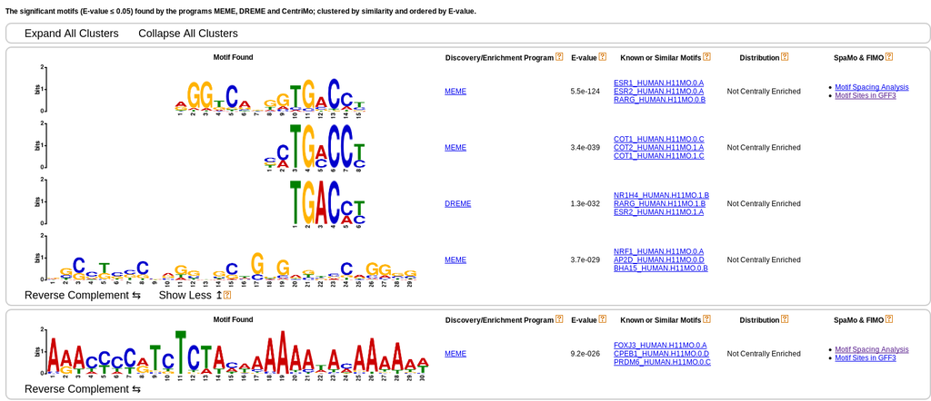

JASPAR CORE (REDUNDANT) database contains a curated set of 719 profiles, derived from published collections of experimentally defined transcription factor binding sites for eukaryotes.

```
    Arguments ok
    Starting MEME-ChIP
    meme-chip -oc . -time 300 -ccut 100 -fdesc description -order 1 -db db/JASPAR/JASPAR2018_CORE_vertebrates_redundant.meme -meme-mod zoops -meme-minw 6 -meme-maxw 30 -meme-nmotifs 5 -meme-searchsize 100000 -dreme-e 0.05 -centrimo-score 5.0 -centrimo-ethresh 10.0 seq_nodup_output1.fasta
    MEME-ChIP is starting subprocess getsize
    getsize ./seq_nodup_output1.fasta 1> $metrics
    MEME-ChIP subprocess getsize ran successfully in 0.0 seconds
    MEME-ChIP is starting subprocess fasta-most
    fasta-most -min 50 < ./seq_nodup_output1.fasta 1> $metrics
    MEME-ChIP subprocess fasta-most ran successfully in 0.2 seconds
    MEME-ChIP is starting subprocess fasta-center
    fasta-center -dna -len 100 < ./seq_nodup_output1.fasta 1> ./seqs-centered
    MEME-ChIP subprocess fasta-center ran successfully in 0.2 seconds
    MEME-ChIP is starting subprocess fasta-shuffle-letters
    fasta-shuffle-letters ./seqs-centered ./seqs-shuffled -kmer 2 -tag -dinuc -dna -seed 1
    MEME-ChIP subprocess fasta-shuffle-letters ran successfully in 0.0 seconds
    MEME-ChIP is starting subprocess fasta-get-markov
    fasta-get-markov -nostatus -nosummary -dna -m 1 ./seq_nodup_output1.fasta ./background
    MEME-ChIP subprocess fasta-get-markov ran successfully in 0.0 seconds
    MEME-ChIP is starting subprocess meme
    meme ./seqs-centered -oc meme_out -mod zoops -nmotifs 5 -minw 6 -maxw 30 -bfile ./background -dna -searchsize 100000 -time 5082 -revcomp -nostatus
    MEME-ChIP subprocess meme ran successfully in 4035.4 seconds
    MEME-ChIP is starting subprocess dreme
    dreme -verbosity 1 -oc dreme_out -png -dna -p ./seqs-centered -n ./seqs-shuffled -t 5525 -e 0.05
    MEME-ChIP subprocess dreme ran successfully in 120.6 seconds
    MEME-ChIP is starting subprocess centrimo
    centrimo -seqlen 299 -verbosity 1 -oc centrimo_out -bfile ./background -score 5.0 -ethresh 10.0 ./seq_nodup_output1.fasta meme_out/meme.xml dreme_out/dreme.xml db/JASPAR/JASPAR2018_CORE_vertebrates_redundant.meme
    MEME-ChIP subprocess centrimo ran successfully in 2.8 seconds
    MEME-ChIP is starting subprocess tomtom
    tomtom -verbosity 1 -oc meme_tomtom_out -min-overlap 5 -dist pearson -evalue -thresh 1 -no-ssc meme_out/meme.xml db/JASPAR/JASPAR2018_CORE_vertebrates_redundant.meme
    MEME-ChIP subprocess tomtom ran successfully in 62.4 seconds
    MEME-ChIP is starting subprocess tomtom
    tomtom -verbosity 1 -oc dreme_tomtom_out -min-overlap 5 -dist pearson -evalue -thresh 1 -no-ssc dreme_out/dreme.xml db/JASPAR/JASPAR2018_CORE_vertebrates_redundant.meme
    MEME-ChIP subprocess tomtom ran successfully in 3.1 seconds
    MEME-ChIP is starting subprocess tomtom
    tomtom -verbosity 1 -text -thresh 0.1 ./combined.meme ./combined.meme 1> ./motif_alignment.txt
    MEME-ChIP subprocess tomtom ran successfully in 1.5 seconds
    MEME-ChIP is starting subprocess spamo
    spamo -verbosity 1 -oc spamo_out_1 -bgfile ./background -keepprimary -primary RGGTCADGGTGACCT ./seq_nodup_output1.fasta meme_out/meme.xml meme_out/meme.xml dreme_out/dreme.xml db/JASPAR/JASPAR2018_CORE_vertebrates_redundant.meme
    MEME-ChIP subprocess spamo ran successfully in 67.6 seconds
    MEME-ChIP is starting subprocess spamo
```

[output cut: 33 more lines]

```
    fimo --parse-genomic-coord --verbosity 1 --oc fimo_out_5 --bgfile ./background --motif CCTGSCY dreme_out/dreme.xml ./seq_nodup_output1.fasta
    MEME-ChIP subprocess fimo ran successfully in 0.5 seconds
    MEME-ChIP is starting subprocess fimo
    fimo --parse-genomic-coord --verbosity 1 --oc fimo_out_6 --bgfile ./background --motif RTGACTCA dreme_out/dreme.xml ./seq_nodup_output1.fasta
    MEME-ChIP subprocess fimo ran successfully in 0.5 seconds
    MEME-ChIP is starting subprocess fimo
    fimo --parse-genomic-coord --verbosity 1 --oc fimo_out_7 --bgfile ./background --motif AGAWAA dreme_out/dreme.xml ./seq_nodup_output1.fasta
    MEME-ChIP subprocess fimo ran successfully in 0.5 seconds
    MEME-ChIP is starting subprocess fimo
    fimo --parse-genomic-coord --verbosity 1 --oc fimo_out_8 --bgfile ./background --motif RCACACA dreme_out/dreme.xml ./seq_nodup_output1.fasta
    MEME-ChIP subprocess fimo ran successfully in 0.5 seconds
    MEME-ChIP is starting subprocess meme-chip_html_to_tsv
    meme-chip_html_to_tsv ./meme-chip.html ./summary.tsv "meme-chip -oc . -time 300 -ccut 100 -fdesc description -order 1 -db db/JASPAR/JASPAR2018_CORE_vertebrates_redundant.meme -meme-mod zoops -meme-minw 6 -meme-maxw 30 -meme-nmotifs 5 -meme-searchsize 100000 -dreme-e 0.05 -centrimo-score 5.0 -cen…
    MEME-ChIP subprocess meme-chip_html_to_tsv ran successfully in 0.3 seconds
    MEME-ChIP ran successfully in 4511.02 seconds
```

##### **Results**

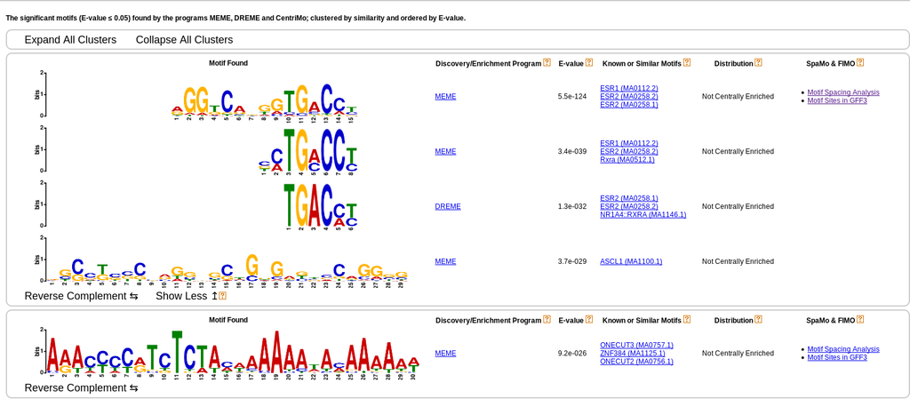

The above analysis produced results which were same in terms of the sequence of the motifs were the same, but when cross-checked with the different known motifs databases, they produced different results. The similar motifs for the results, excluding the first significant motif, did *not* converge.

The converging results are:

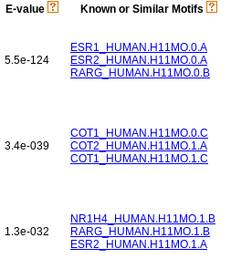

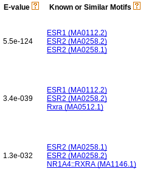

The similar motifs found point towards ESR1 and ESR2. The E-values, p-values and q-values, though different, are proximal.

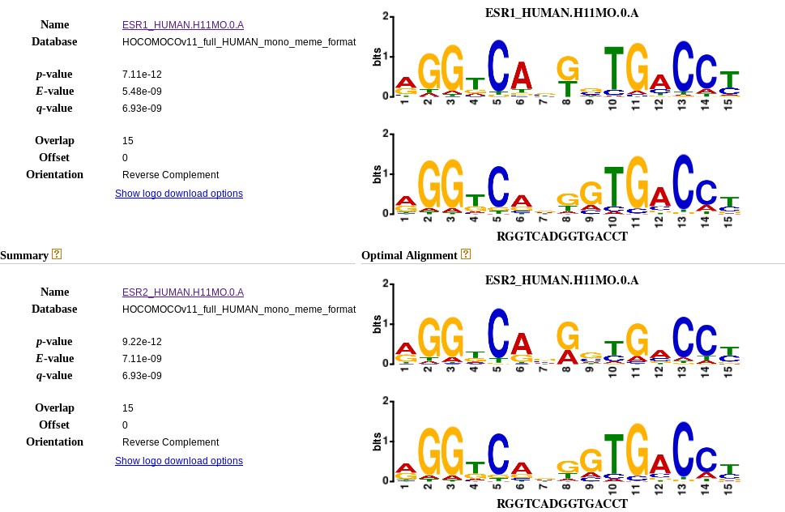

*HOCOMO Motifs(TOMTOM)*

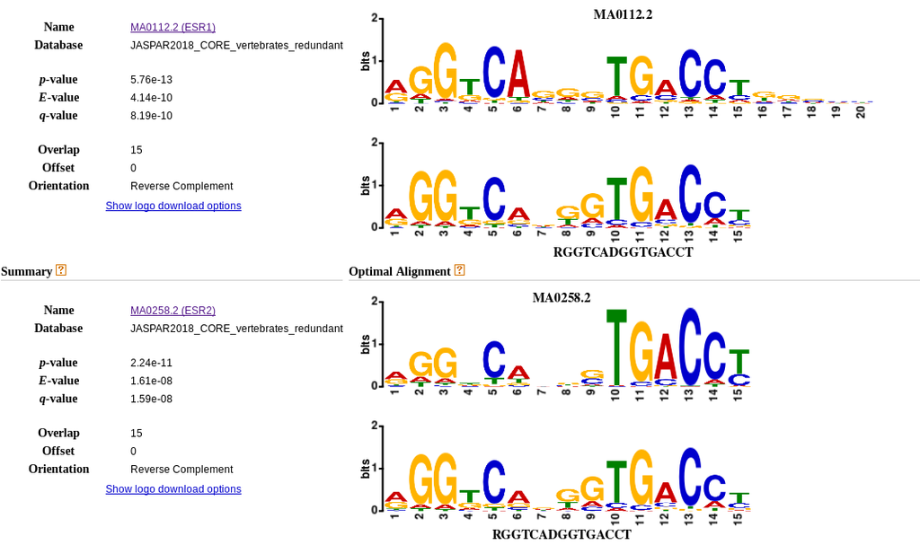

*JASPER Motifs(TOMTOM)*

#### Footnotes on ESRX

- ESR1: (Estrogen receptor)
  - Nuclear hormone receptor. The steroid hormones and their receptors are involved in the regulation of eukaryotic gene expression and affect cellular proliferation and differentiation in target tissues. Can activate the transcriptional activity of TFF1(Breast Cancer Estrogen-Inducible Protein)
- ESR2: (Estrogen receptor beta)
  - Nuclear hormone receptor. Binds estrogens with an affinity similar to that of ESR1, and activates expression of reporter genes containing estrogen response elements (ERE) in an estrogen-dependent manner.

#### RSAT

RSAT provides a set of tools to analyse cis-regulatory elements in genome sequences. This part of the analysis was performed to check if the results differed when using different motif discovery tools.

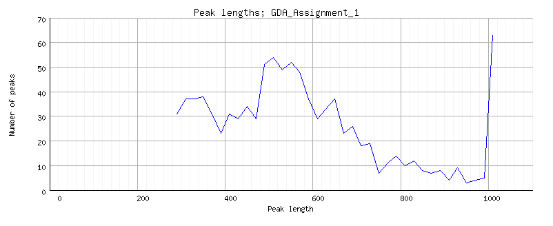

*Peak Counts vs Peak Lengths*

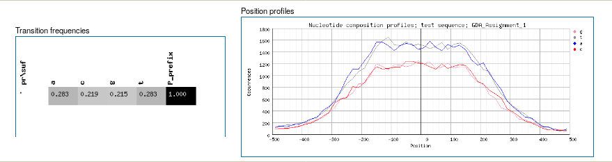

*Nucleotide Frequencies*

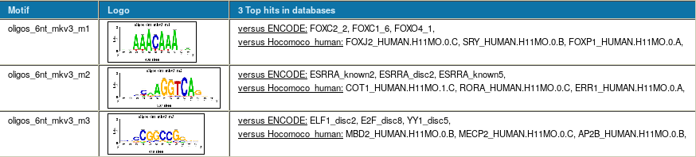

*Top motifs and their similar genes*

Most of the motifs analyzed are different from the results obtained from MEME-ChIP. But it points to some interesting Candidates like FOXP1 which acts as a repressor gene, ERRq(ESRRA) which acts like an estrogen receptor.

### Analysis

[Factorbook](http://www.factorbook.org/human/chipseq/tf/ESR1#) breifly explain that estrogen receptors are involved in pathological processes including breast cancer, endometrial cancer, and osteoporosis. Alternative promoter usage and alternative splicing result in dozens of transcript variants, but *the full-length nature of many of these variants has not been determined.* On browsing the genes associated with ESR1, [UCSC Genes](https://genome.ucsc.edu/cgi-bin/hgTracks?clade=mammal&org=Human&db=hg19&position=ESR1&hgt.positionInput=ESR1&hgt.suggestTrack=knownGene&Submit=submit) shows that the following genes are in direct association and reside in the 21st chromosome(which is the current chromosome under observation)

- [NRIP1](https://genome.ucsc.edu/cgi-bin/hgTracks?position=chr21:16333556-16437126&hgsid=710379003_0gzAEJXCBGN4dcDr9AROqjrCuEDd&knownGene=full&hgFind.matches=uc002yjx.2,)
- [PRMT2](https://genome.ucsc.edu/cgi-bin/hgTracks?position=chr21:48055507-48085155&hgsid=710379003_0gzAEJXCBGN4dcDr9AROqjrCuEDd&knownGene=full&hgFind.matches=uc002zjy.3,)

Viewing these genes on the [UCSC Genome Browser](https://genome.ucsc.edu/cgi-bin/hgTracks?hgsid=710342469_7I9mLKhyJ8OAqw3VO0zLcAxQVnhH) uncovered that at chr21:46,902,033-46,902,170, ESR1 was directly in line with the Peak Track.

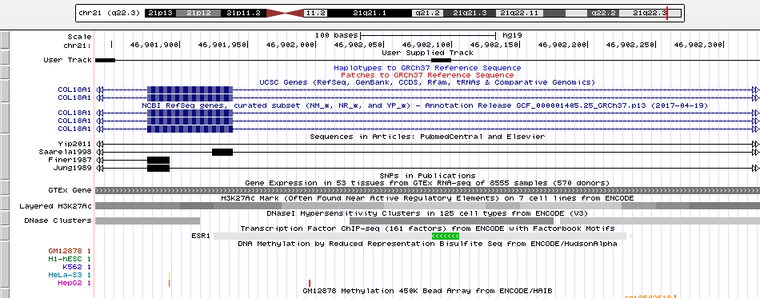

*Estrogen Binding*

A similar entry was found in the positions of motifs found by MEME. It had the sequence AGGTCAGGGTGACCT and was located in chr21:46901839-46902327. This looks like a potential binding by a TF at the span of the region, owing to it prefixing a TSS.

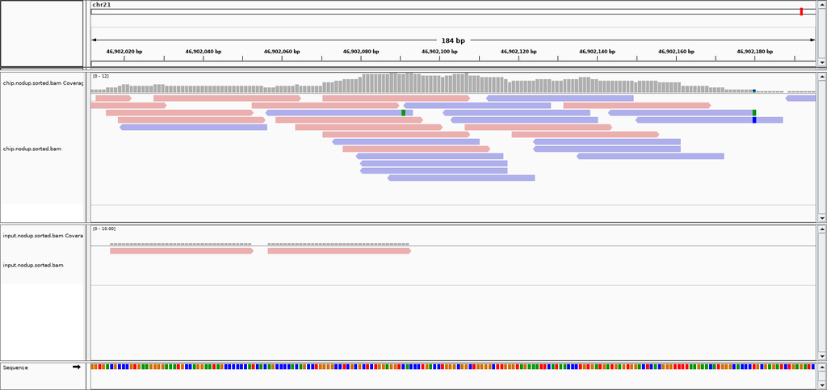

*IGV shows a peak at the region spanning the motif location*

## Conclusion

Thus this report is concluded with a good confidence level that this is the expected binding motif of ESR1 transcription factor.